# Lab 4: Data visualization (continued)

Elena Tuzhilina

Sep 30, 2021

**Note: There are often multiple ways to answer each question.**

```r
library(ggplot2)
library(fueleconomy)
data(vehicles)
vehicles <- vehicles[1:2000, ]
```

1. Make a scatterplot of `hwy` vs. `cty`. Give axis titles and a main title to the plot to make it more interpretable.

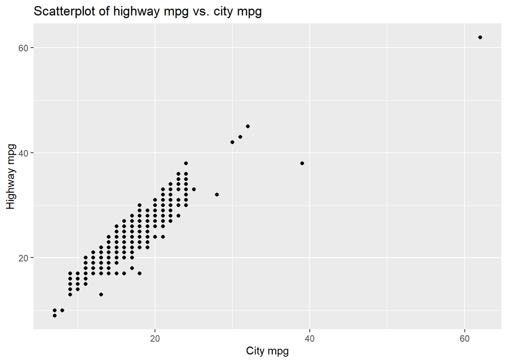

```r
ggplot(vehicles, aes(x = cty, y = hwy)) +
    geom_point() +
    labs(title = "Scatterplot of highway mpg vs. city mpg", x = "City mpg",
         y = "Highway mpg")
```

2. Modify the plot above such that the color of the dot represents `cyl` value. Also reduce the alpha of the points to an appropriate level and introduce jitter.

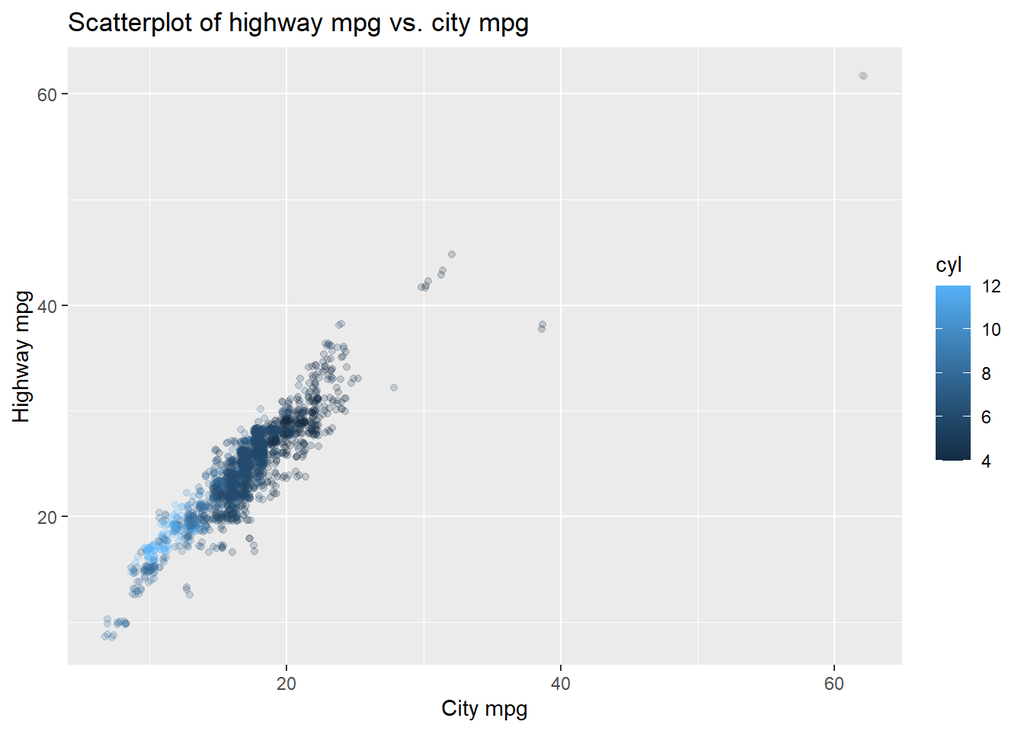

```r
ggplot(vehicles, aes(x = cty, y = hwy, col = cyl)) +
    geom_jitter(alpha = 0.2) +
    labs(title = "Scatterplot of highway mpg vs. city mpg", x = "City mpg",
         y = "Highway mpg")
```

3. Modify the plot above so that each value of `cyl` is in its own plot.

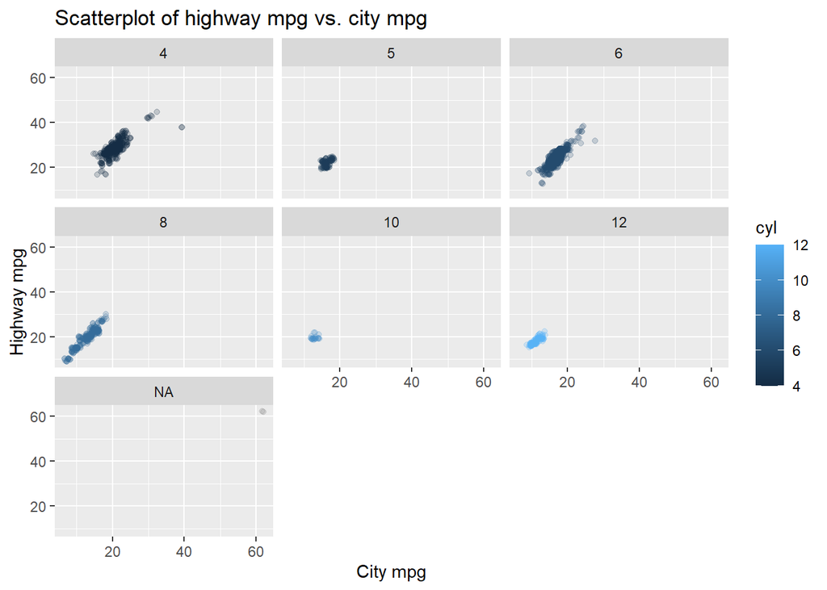

```r
ggplot(vehicles, aes(x = cty, y = hwy, col = cyl)) +
    geom_jitter(alpha = 0.2) +
    labs(title = "Scatterplot of highway mpg vs. city mpg", x = "City mpg",
         y = "Highway mpg") +
    facet_wrap(~ cyl)
```

4. While the plot above gives us a good idea of how cars with different `cyl` values compare with each other, a lot of the plot space is wasted. Modify the plot so that each little plot has its own x and y scale. (Hint: [This website](https://www.rdocumentation.org/packages/ggplot2/versions/3.2.1/topics/facet_wrap) might be helpful.)

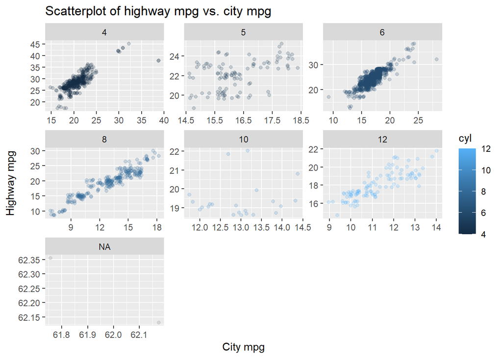

```r
ggplot(vehicles, aes(x = cty, y = hwy, col = cyl)) +
    geom_jitter(alpha = 0.2) +
    labs(title = "Scatterplot of highway mpg vs. city mpg", x = "City mpg",
         y = "Highway mpg") +
    facet_wrap(~ cyl, scales = "free")
```

5. Make a barplot to show how many cars of each type of `fuel` there are in the dataset. (Use the `geom_bar` geom.) Change the theme to `ggplot`’s black and white theme.

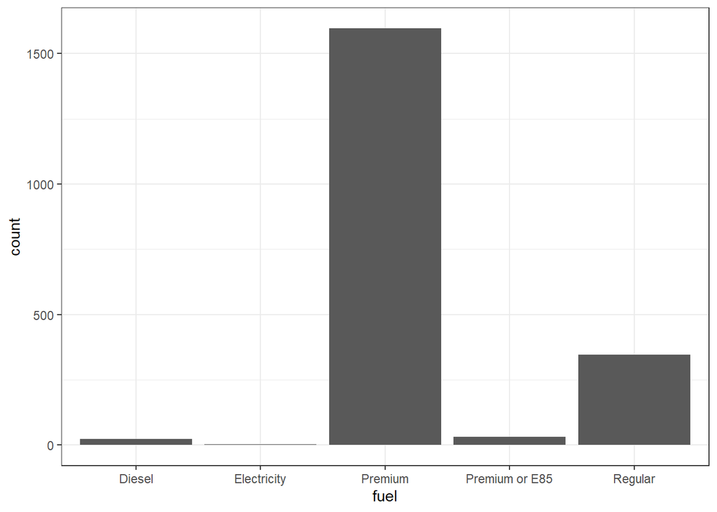

```r
ggplot(vehicles, aes(x = fuel)) +
    geom_bar() +
    theme_bw()
```

6. Make a violin plot to show the distribution of `displ` for each value of `drive`. Overlay that with a scatterplot of `displ` vs. `drive` (with jitter and alpha). How does the scatterplot give the reader more information?

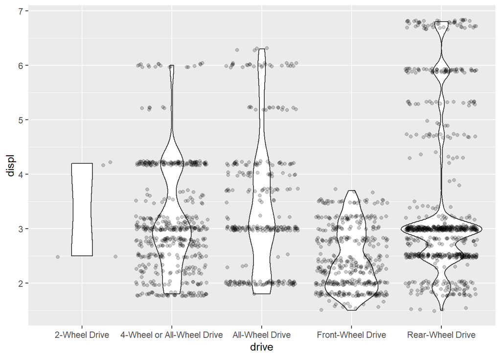

```r
ggplot(vehicles, aes(x = drive, y = displ)) +
    geom_violin() +
    geom_jitter(alpha = 0.2)
```

The scatterplot shows us how many observations there really are for each value of `drive`. The violin plot doesn’t convey that information well. (For example, there are very few observations with 2-Wheel Drive.)

7. Make a (jittered) scatterplot of `hwy` against `year` with alpha value 0.5. Add a `geom_smooth` layer with option `method = "lm"` and without the SE bands.

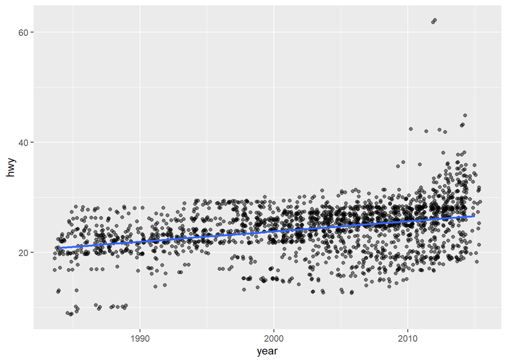

```r
ggplot(vehicles, aes(x = year, y = hwy)) +
    geom_jitter(alpha = 0.5) +
    geom_smooth(method = "lm", se = FALSE)
```

8. Modify the previous plot so that the color of the points depends on `fuel`. Also, change the theme to `ggplot`’s minimal theme and move the legend to the bottom of the plot. What happens to the `geom_smooth` layer?

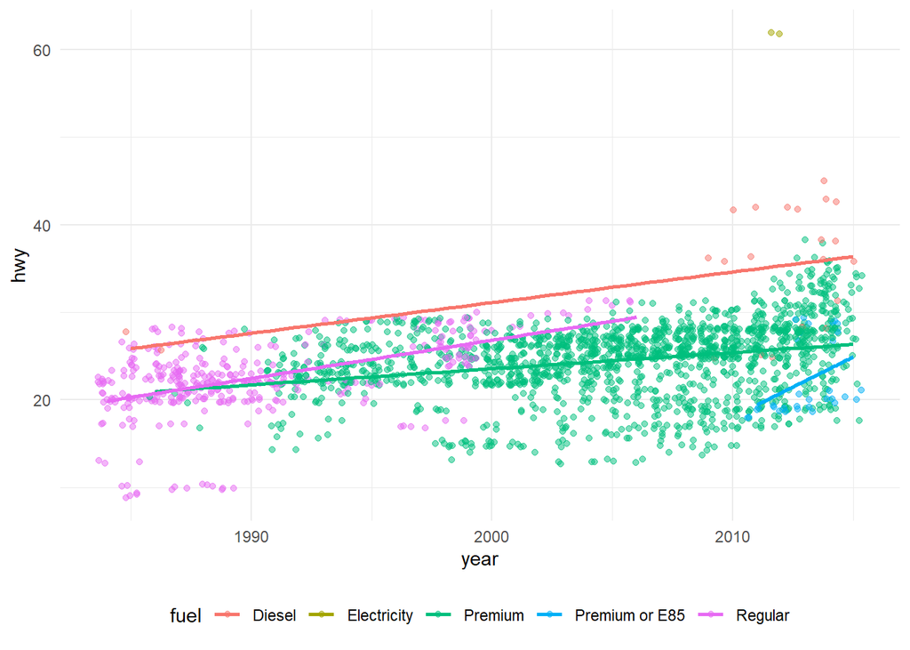

```r
ggplot(vehicles, aes(x = year, y = hwy, col = fuel)) +
    geom_jitter(alpha = 0.5) +
    geom_smooth(method = "lm", se = FALSE) +
    theme_minimal() +
    theme(legend.position = "bottom")
```

The `geom_smooth` layer gives a separate smoothed estimate for each value of `fuel`.

9. Make a (jittered) scatterplot of `hwy` vs. `cty`, with the color of the point depending on `year`. Change the color scale to “Spectral”. Do you see a trend?

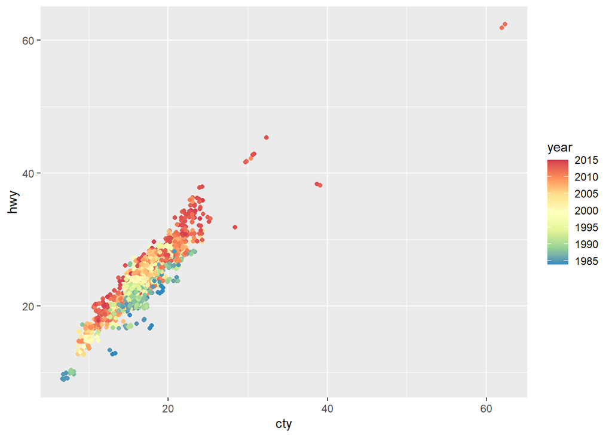

```r
ggplot(vehicles, aes(x = cty, y = hwy, col = year)) +
    geom_jitter() +
    scale_color_distiller(palette = "Spectral")
```

As time goes on, we tend to see higher values of both highway and city mpg. This makes sense, since we expect the cars to be more fuel-efficient as time goes on.

10. Modify the theme of the plot above to a theme you like and try a different color scale. Also, give the plot a title and make it bigger, bold and centralized.

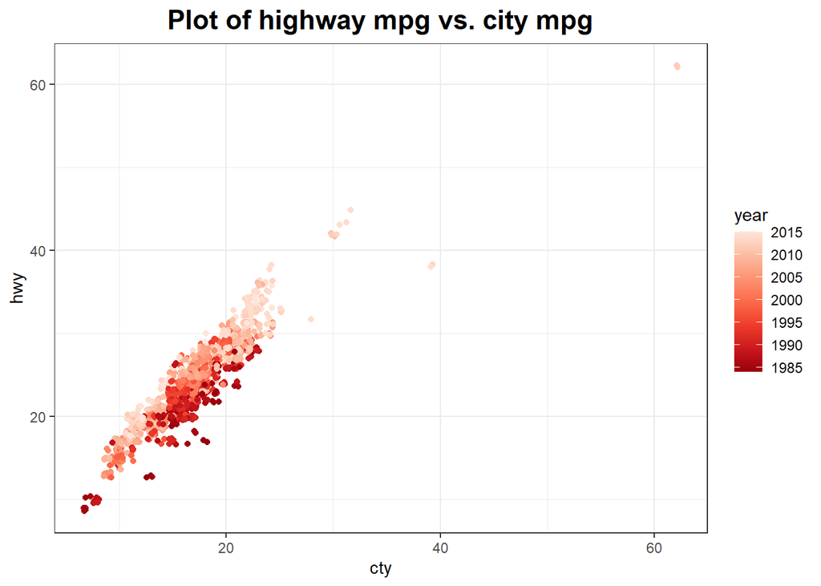

```r
ggplot(vehicles, aes(x = cty, y = hwy, col = year)) +
    geom_jitter() +
    scale_color_distiller(palette = "Reds") +
    labs(title = "Plot of highway mpg vs. city mpg") +
    theme_bw() +
    theme(plot.title = element_text(size = rel(1.5), face = "bold", hjust = 0.5))
```